# Analyzing resting-state EEG and Spelling Performance in Young Adults (Quadratic Plateau) VERSION2

Leandro Ledesma

2026-01-29

**DISCLAIMER: Code compatible to run on Lisa’s TIMES Computer**

**This is supposed to be a shorter version (summary) of the Rmarkdown with the original analysis**

### Universal block code settings

```r
knitr::opts_chunk$set(echo = FALSE)
knitr::opts_chunk$set(message = FALSE)
knitr::opts_chunk$set(comment = NULL)
knitr::opts_chunk$set(warning = FALSE)
```

### Loading in our data and doing some data cleaning

Here we are loading demographic and medical information

- demographic information (age, sex)
- Medical information (to remove DD or head injuries)

After some minor data cleaning we combine the information into one dataset.

### Number of Recruited Subjects

Our original excel file that contains all IDs in our MegaGrant dataset is a little bit complex- kinda. Basically it includes IDs from two studies, that of STUDY1 that is of interest to us and STUDY3, which is not. We need to identify only the IDs that are a part of STUDY1 and remove studies that only correspond to STUDY3. We use the word only because most IDs were present in both studies

```
There are  674 unique IDs in this dataset
```

```
After removing IDs that only corresponded to STUDY3 but not STUDY1, we have 651 IDs
```

### Loading in the ARFA Spelling data

- Here we will be loading ARFA spelling error data. This data has already been processed from an earlier script where each item had the potential to have several different types of errors. For example, each item had 7 variables where scores were given to indicate errors or even Russian words were used. No errors were rows where each of the 7 variables had all 0’s, which was most of the dataset. What we are loading in below are **sum of errors for each item** capped at two (0, 1, 2). We capped it at two because that was recommended to us.

### Visualizing the ARFA Spelling Data

Below we can visualize the distribution of total item error score (not the same as total number of incorrect items). Additionally, we can see the frequency of the number of errors by item.

Descriptive Statistics of Spelling Total Error Score

| vars | n | mean | sd | median | trimmed | mad | min | max | range | skew | kurtosis | se |
| --- | --- | --- | --- | --- | --- | --- | --- | --- | --- | --- | --- | --- |
| 1 | 661 | 14.97 | 9.63 | 13 | 14.15 | 10.38 | 0 | 41 | 41 | 0.65 | -0.41 | 0.37 |

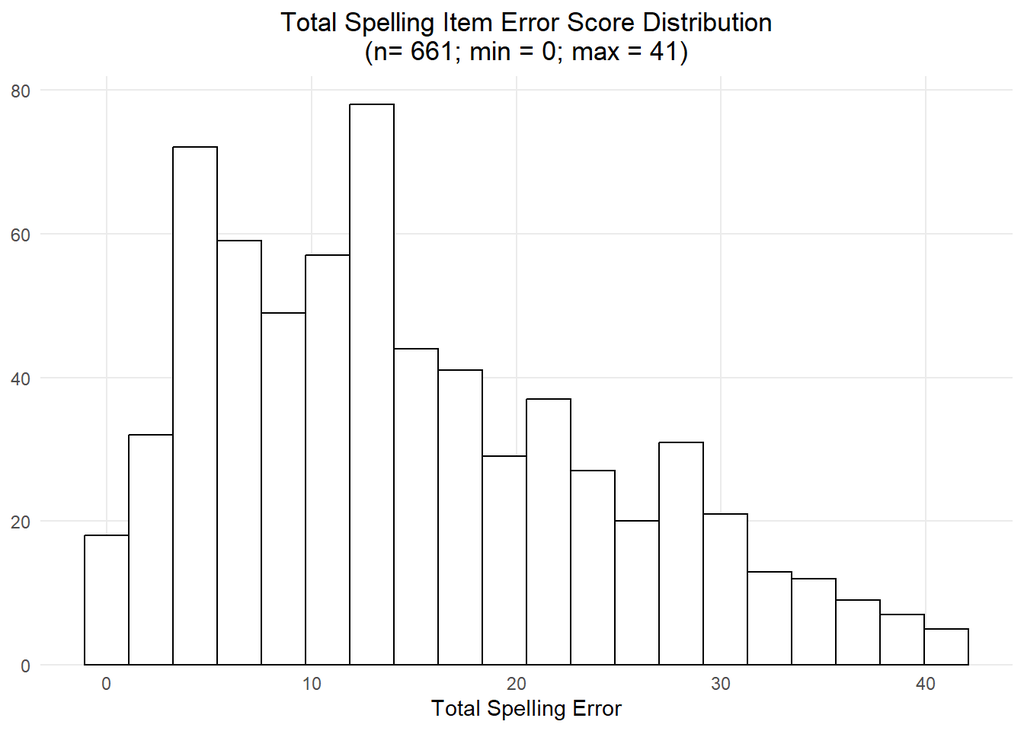

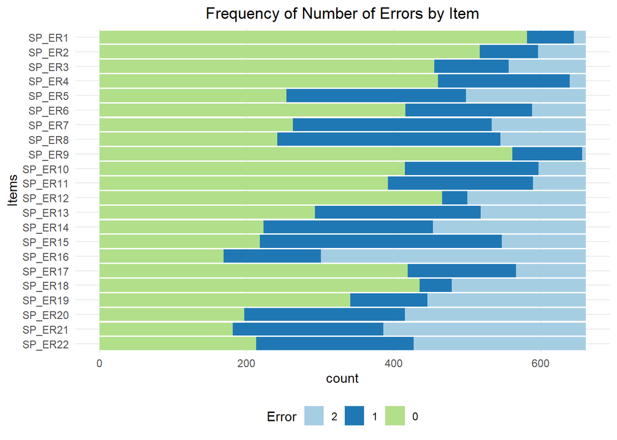

### Running a Graded Response Model (Item Reponse Theory Model)

We technically already did this in another R script. However, we will be redoing it again here to explain exactly how the process works better. Essentially, from the graphs above, we can see that each item contains 3 different types of categories (no mistakes = 0, one mistake = 1, at least two mistakes = 2). Thus, we can use a **graded response model** to basically estimate difficulty and discrimination parameters for each item. Additionally, we can extract standardized error scores for each observation (ID), which we will use as a precursor for our predictor of interest.

The model produces standardized error scores, but then we multiplied these values by **negative one** to turn them into accuracy measures. Afterwards, we introduce these values into our main dataset with demographic and medical information.

What is plotted are the original theta values that represent errors. Additionally we show another plot that shows the graded response model parameters, indicating item level information. Unfortunately, I have no idea how to interpret these values.

```
Calculating information matrix...
```

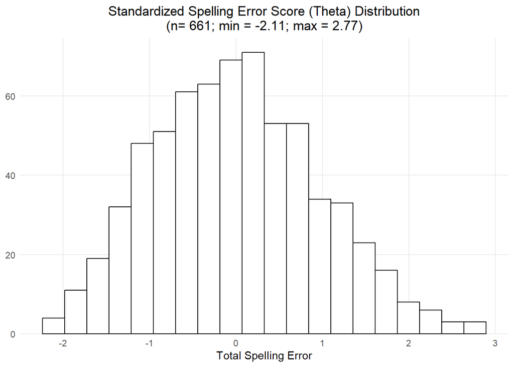

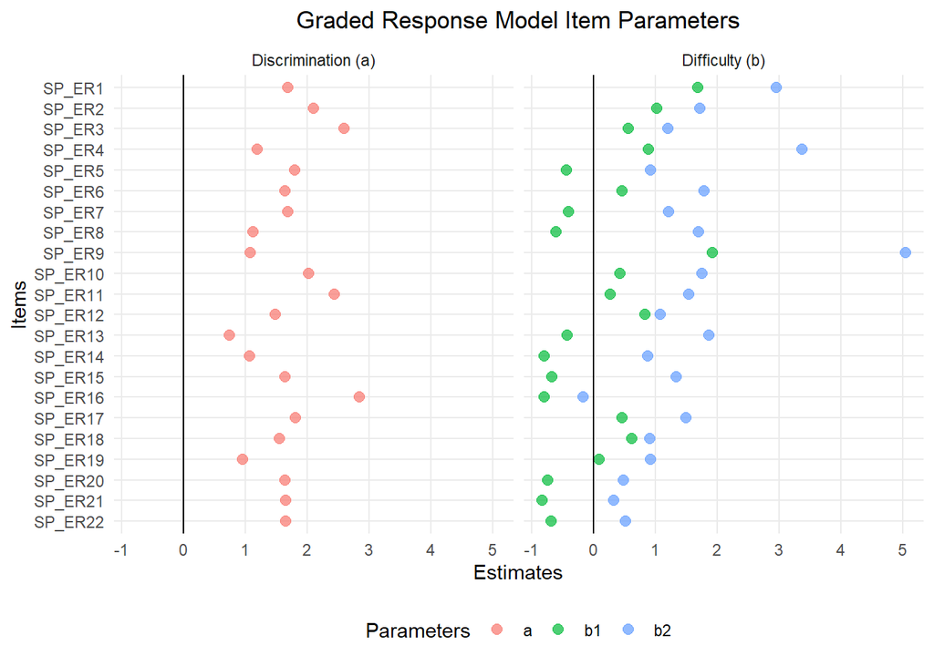

### Loading EEG Information

Here we are loading two types of EEG information:

- Individual power spectra (FFT) of rsEEG recordings
- An EEG quality control (QC) CSV

The **power spectra** holds information of our resting-state EEG outcome. The analysis in subsequent sections will be attempting to explain the variance of this for the several frequency bands. The QC will be used to remove recordings that were problematic during the preprocessing stage- this occurs in the next section.

During this data cleaning code section, we are:

- Identifying two rsEEG recordings that need to be renamed
- Removing data from 5 recordings, one which was redundant, four because they were not real IDs (not sure what they are)
- Use interpolated channel x trial segments to identify channels as ‘bad’ (e.g., if 90% of the channel was interpolated then we should mark that as a bad channel)

The information in this section should **not** count toward reporting ‘x’ number of IDs removed

```
rsEEG IDs that need to be renamed (RAW -> ID)
```

```
# A tibble: 2 × 2
  ID    RAW
  <chr> <chr>
1 34867 34857
2 97991 97911
```

```
It it should say 0 below if it worked and IDs were renamed
```

```
[1] 0
```

### Remove subjects that do not meet criteria (Behaviorally)

This is the exclusion criteria: - Self-report injury - Epilepsy - ADD - Too old compared to average (more than 3 Sd from the mean) - Do not have spelling data (this is information is needed to make spelling groups later on) - **Note**: Calculating z-scores must be done before removing any IDs from the dataset- this prevents recalculating z-scores and have another extreme value appear when previously it wasn’t!

*Update- modification occurred, we will now keep dyslexics and ppl with low performance on the CFIT in the data*

We use the `slice_head()` function since this is information from level-2 predictors- this will speed up the code.

Here we will be removing subjects that do not meet the behavior criteria. There is another section that will follow where we further exclude subjects who do not have adequate EEG data.

```
We are starting out with 659 unique ids that have at least one eyes open/closed rsEEG recording
```

```
We are removing 143 participants for having head trauma, epilepsy, autism, ADD, extremly poor spellers (3SD +), or older than 3SD from the mean
```

```
  HeadTrauma Health2epilepsy Health2autism ADD Dislexia Too_old MissingSpell
N        108             141           142  50      125     133          126
Y         35               2             1  93       18      10           17
```

```
This leaves us with data from 516 participants who may or may not have an EEG recording
```

```
numeric(0)
```

```
numeric(0)
```

### Early Demographics

The demographics before we removed bad EEG recordings - The sample size for Age is three less than it should be because of NAs

```
   vars   n  mean   sd median trimmed  mad min max range skew kurtosis   se
X1    1 513 20.12 4.29     19   19.43 2.97  15  33    18 1.27     0.91 0.19
```

```
   F    M
0.57 0.43
```

```
 BF  IC
271 242
```

```
[1] "516 unique IDs"
```

### Descriptives of QC of our EEG data (Eyes Closed Only)

Below we can visualize different EEG QC measures to get a feel for how problematic EEG recordings were and in which aspect. These QC metrics were derived from MATLAB preprocessing code where custom functions were used to identify number of bad channels, trials, and overall data interpolation. With the exception of bad trials that used a threshold of SD =4, every other metric used a threshold of SD = 5. Specifically, this was using robust zscores since they are less likely to be inflated by skewed data.

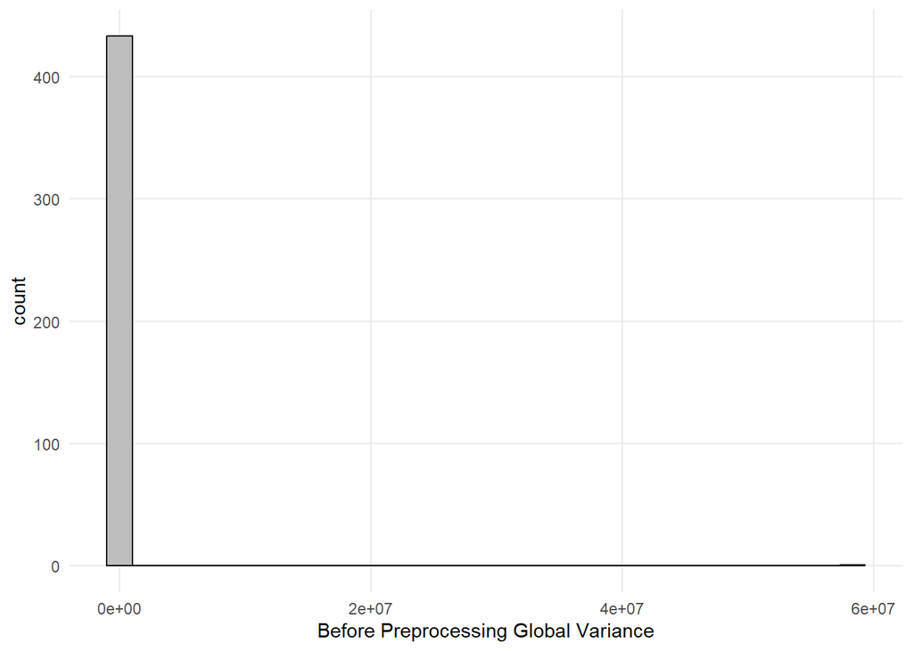

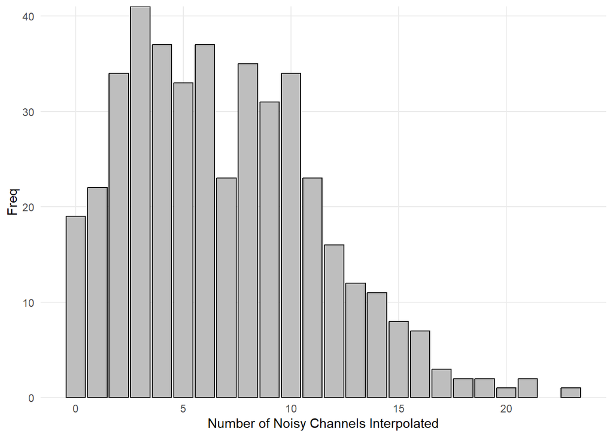

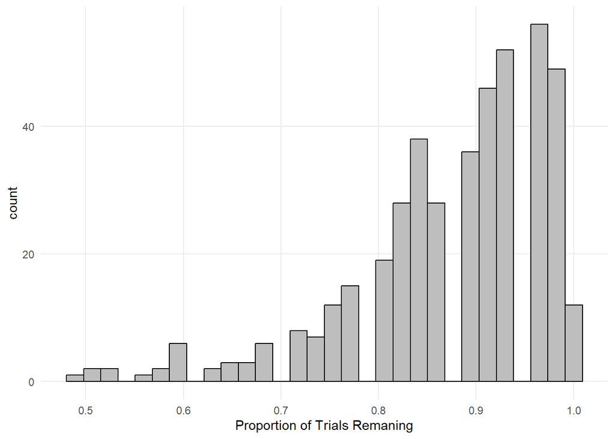

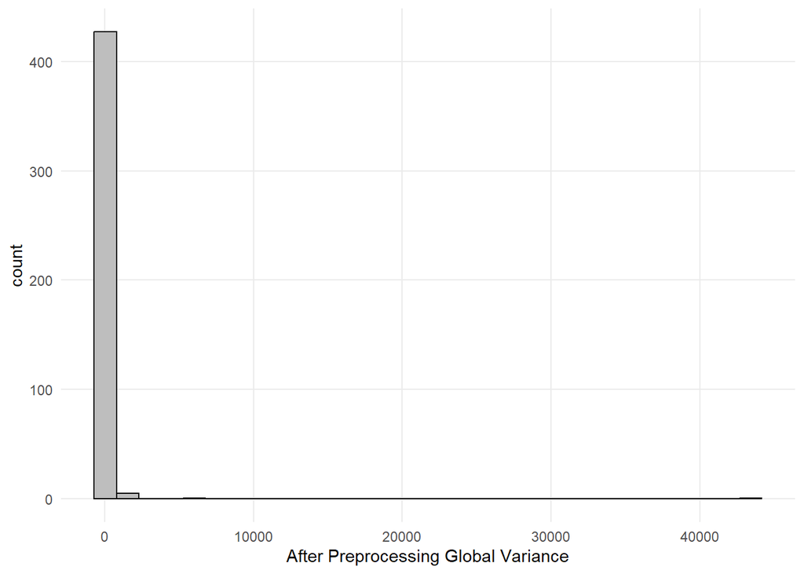

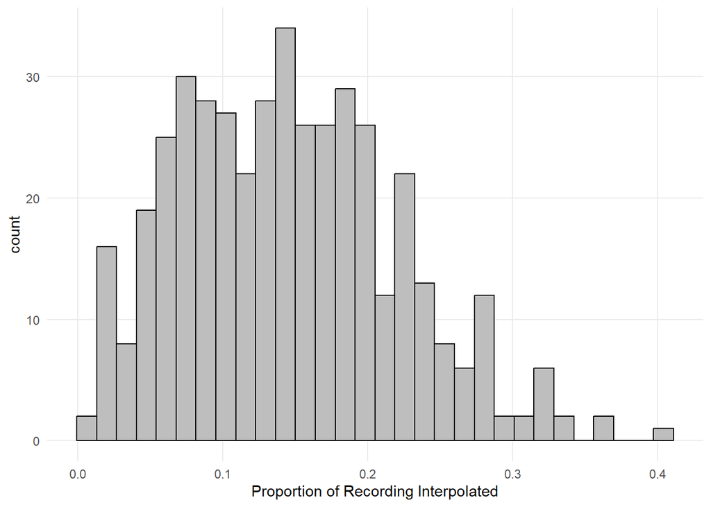

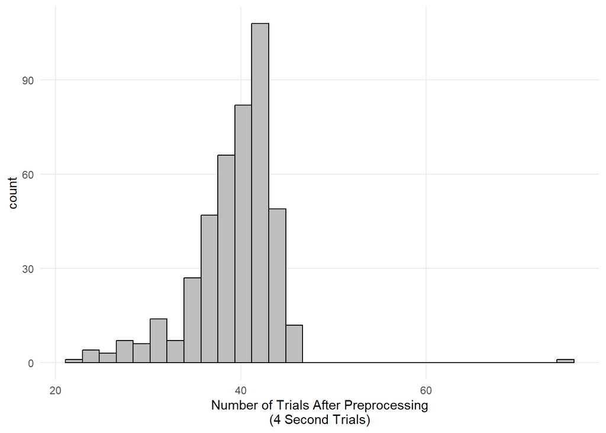

#### Identifying how many EEG recordings are good

Below we specified what makes a good recording. The recordings need to:

- Have less than 18% of channels be interpolated or marked as bad. Since there are 62 channels in each recording, 62 * .18 = 11.16. Thus, if a recording has 12 or more bad channels they will not be used for analysis.
- Have at least 30 trials, each being 4 seconds long, which will result in 2 minutes worth of EEG recordings.
- Have missing EEG data, they will be fully removed.
- And if their ending global variance is larger than 4 robust z-scores then they will be removed. This means that we calculate the MAD score instead of the standard deviation, which is more robust to outliers, and multiply this value by 4 and add it to the mean of ending global variance. Any recordings with an ending global variance that exceeds this threshold will be removed.

```
Recordings split by whether they have enough trials (min = 30 )
```

```
Not_Engh_EEG
  N   Y
416  18
```

```
Recordings split by whether they exceed acceptable channel interpolation proportion from  62  channels (max = 0.18 )
```

```
Many_Chan_Intp
  N   Y
369  65
```

```
Had an ending global variance that exceeded 4 MAD above the mean
```

```
HigEndVar
  N   Y
427   7
```

```
IDs that did not have EEG data at all
```

```
Missing_EEG
  N   Y
434  82
```

```
Number and percentage of recordings that need to be excluded
```

```
Exclusion
  N   Y
352 164
```

```
Exclusion
   N    Y
0.68 0.32
```

```
Missing data of the observations (IDs) that will be used in the final analysis
```

```
             S1              S3              ID             Sex             Age
              0             323               0               0               0
          Group      HeadTrauma Health2epilepsy   Health2autism             ADD
              0              30             352             352              30
       Dislexia      theta_good       Condition     start_trial   start_globvar
             30               0               0               0               0
      trialsrmv       end_trial trialpropremain     end_globvar       int_total
              0               0               0               0               0
        channel       frequency           power        elec_pop       elec_flat
              0               0               0               0               0
      elec_nois         int_AF3         int_AF4         int_AF7         int_AF8
              0               0               0               0               0
        int_AFz          int_C1          int_C2          int_C3          int_C4
              0               0               0               0               0
         int_C5          int_C6         int_CP1         int_CP2         int_CP3
              0               0               0               0               0
        int_CP4         int_CP5         int_CP6         int_CPz          int_Cz
              0               0               0               0               0
         int_F1          int_F2          int_F3          int_F4          int_F5
              0               0               0               0               0
         int_F6          int_F7          int_F8         int_FC1         int_FC2
              0               0               0               0               0
        int_FC3         int_FC4         int_FC5         int_FC6         int_FCz
              0               0               0               0               0
       int_FT10         int_FT7         int_FT8         int_FT9         int_Fp1
              0               0               0               0               0
        int_Fp2          int_Fz          int_O1          int_O2          int_Oz
              0               0               0               0               0
         int_P1          int_P2          int_P3          int_P4          int_P5
              0               0               0               0               0
         int_P6          int_P7          int_P8         int_PO3         int_PO4
              0               0               0               0               0
        int_PO7         int_PO8         int_POz          int_Pz          int_T7
              0               0               0               0               0
         int_T8         int_TP7         int_TP8        chan_rmv       chan_rmv2
              0               0               0               0               0
   Not_Engh_EEG  Many_Chan_Intp     Missing_EEG       HigEndVar       Exclusion
              0               0               0               0               0
```

# Introducing Topography and Frequency Band Variables

We will start with the information present in the data frame that was created in the previous section. We will use the IDs that basically ‘survived’ for having adequate behavioral and EEG data and use that as an index for the dataset that contains all of the within-individual (group) variables (e.g. channels, frequency).

Here we will remove variables (columns) that are not much of interest to us and introduce frequency band (FB) and topography as factors. These factors are designed to simply our data, since right now each recording has power values across individual frequencies (this is also called the **Power Spectra Density**) for each of the 62 electrodes. Eventually we will use these factors to reduce the dimensions of the data, but for now we used the `summary()` function in combination with the `group_by()` function to keep the same dimension. This is so that in subsequent sections we can plot the power spectra without issues.

Also, all recordings below are **eyes closed** only!

The frequency bands chosen follow that from Whitford’s paper (2007), where they had:

- Slow waves: 0.5 - 7.5 Hz
- Alpha waves: 8 - 12 Hz
- Beta waves: 12.5 - 34.5 Hz

- Frontal: c(“Fp1”, “Fp2”, “F7”, “F3”, “Fz”, “F4”, “F8”, “FC3”, “FCz”, “FC4”)
- Temporal: c(“T7”, “TP7”, “T8”, “TP8”)
- Parietal: c(“CP3”, “CPz”, “CP4”, “P3”, “Pz”, “P4”)
- Occipital: c(“O1”, “Oz”, “O2”)

# Plotting the Power Spectra Density (Averaging Across Channels)

Below we are plotting the **power spectral density (PSD)** of our data. This basically means that we have power values (uV^2) for different frequencies (Hz), that’s it, there is nothing more complicated that goes to this. For a source that corroborated this, please visit:

https://liquidinstruments.com/blog/what-is-power-spectral-density-and-why-is-it-important/

Anyway, the PSD is different from **absolute power**, where we take PSD and then sum them within frequency bands. Note that the correct way to calculate absolute power is by taking the sum and not the mean!

If we wanted to calculate relative power, essentially, or the proportion of power explained by that frequency, then we can sum up the power values across the range of our frequencies (0.5 - 35 Hz by 0.25 Hz, which is 139 frequencies) and then just divide each PSD by that sum. The reason why we have power values corresponding to 0.25 Hz is because our EEG segments are 4 seconds long, thus the **frequency resolution**, calculated by 1/seconds = 1/4 seconds = 0.25.

Anyway, thinking about our full long dataset, we have power values that correspond to a range of frequencies (139). Every recording has this information for 62 channels (62 * 139 = 8,618). This is too much information to plot. So instead what we can do is start by averaging across channels within each person, so now every will have a PSD comprised of 139 values that represent the overall PSD. Anyway to accomplish this we can take our long dataset and group it by ID and frequency and obtain an average power across channels- this will be our starting point.

Next, we will take this information and this time average across participants to get a PSD that represents that information for all subjects. This information will then be embedded ontop of the plots as a black line. Now while this is great to visualize, this information is misleading. This is because the aggregate we are plotting is derived from using all channel information in our data. However, as we specified in the previous section, we are only using information from 23 channels in the final analysis, specifically by aggregating across channels of interest within topographical regions of interest. Therefore, we did the same here by averaging across channels of interest within the 4 topographical regions we care for and the plotted that along with the PSD that was further averaged across subjects.

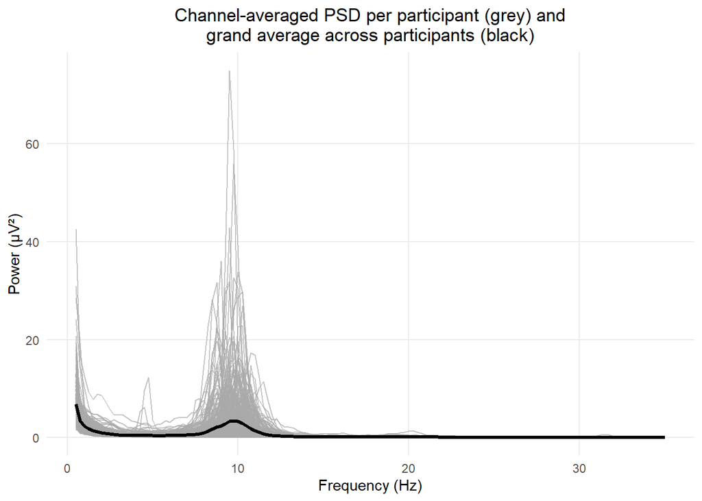

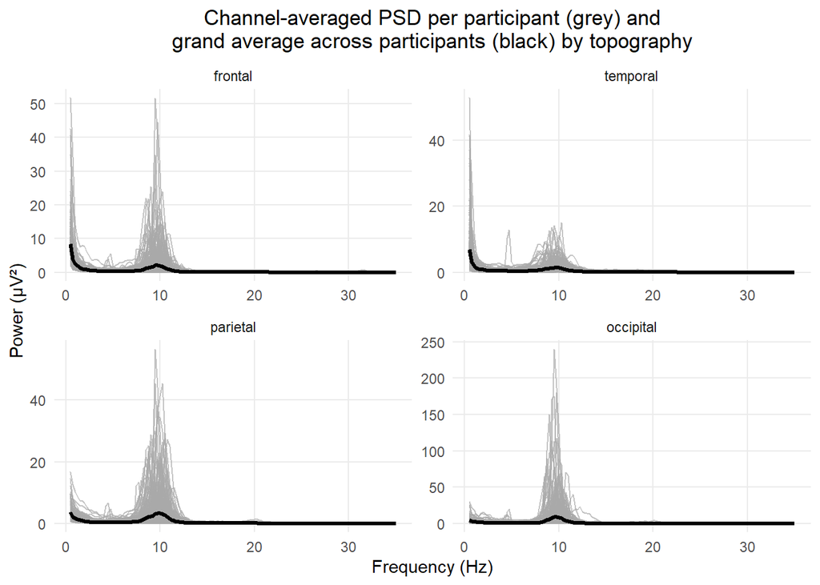

# Calculating Absolute Power (Data Reduction)

We are starting back with our long dataset and this time we will be using it to calculate **absolute power**. We used Grok’s help to basically accomplish this. Okay so we established that each subject has 8,618 observations (62 * 139 = 8,618). We do not care for information from 62 channels, we are only interested in information from 23 of them, so we will start by filtering out channels we do not care for. The easiest way to do this is just to drop observations where topography has NA’s, because these are channels that were not labeled for any of the 4 topography groups.

What we have now per person is 3,197 observations (23 * 139 = 3,197). What we need to do now is simplify our data, or reduce the number of observations by averaging across channels within our frequency bands of interest. This will result in a PSD for 4 topographies for each person (4 * 139 = 556 observations).

Absolute power is defined as the **sum of power values** within frequency bands. So the next step will be to sum power values within topographical regions. We have three frequency bands of interest (slow, alpha, beta), so the 556 observations will be isolated into 4 mutually exclusive groups (topography), from those groups which represent PSD, we will create sub groups of PSD within frequency bands (4 * 3 = 12 topography x frequency band groups), and from these groups we will take the chunked PSD values and sum them together for each person! Additionally, we will multiply this sum by the frequency resolution, which is 0.25. This apparently makes the values actual absolute power, but regardless when we analyze the data we will still get the same results had we not done this.

Therefore, each subject will now have 3 * 4 = 12 power values. With this information, we can also group by either frequency bands or frequency band * topography level combinations and calculate z-scores. In the plots below we can see the consequence of calculating z-scores failing to account for topography, the data becomes very skewed. However when including topography it looks a lot more reasonable, but still skewed. Since we are going to use models that require a normally distributed outcome, we must have to do some transformation to our data.

So in plots below, we also take the log of the outcome and then conver these values into z-scores. From the plots we see that in the log scale values are no longer that extreme, aka not that far away from the mean, which means that our analysis will probably work on our outcome (absolute power) in this scale.

This also means that we do not need to remove subjects for having ‘extreme’ scores since the log scores all look reasonable. Therefore our next section can just be us reporting our final sample size now that the removing subjects phase is concluded.

```
Data points per person, should sum to 12
```

```
           FB
topography  slow alpha beta
  frontal      1     1    1
  temporal     1     1    1
  parietal     1     1    1
  occipital    1     1    1
```

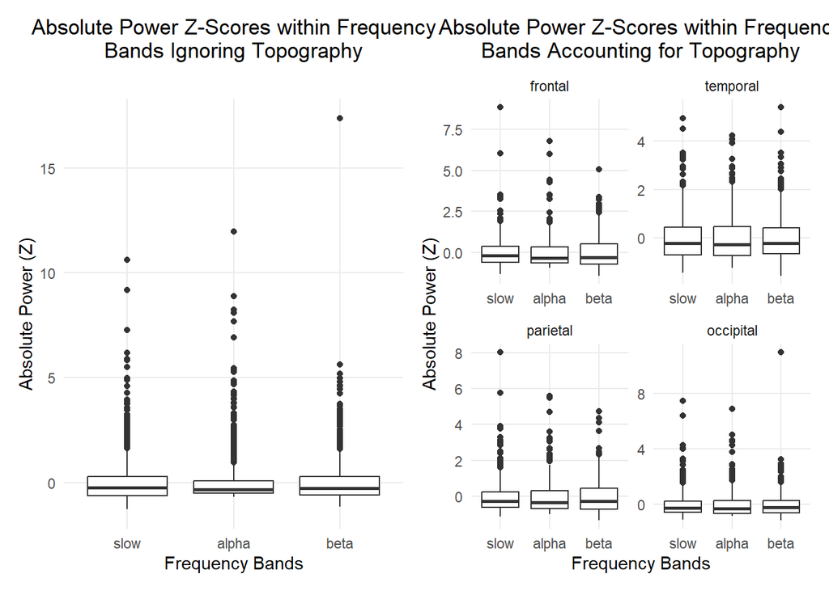

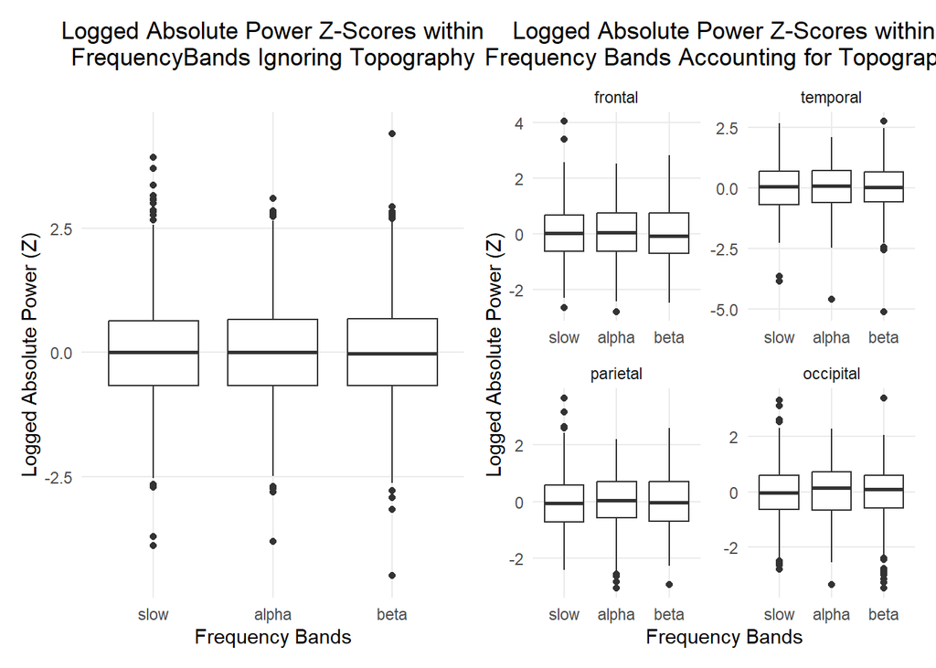

# Final Demographics

From this point on, no observations will be removed from our data. Thus, here we will report our final sample size a long with descriptives of our data. Lastly, we will also show missing values for each variable. There should be no missing values in our predictors, covariates, and outcomes of interest.

```
There are 352 unique IDs in our sample and each one should have 12 observations, for a total of 4224 observations
```

```
Counting the number of rows in the data, there are 4224 rows
```

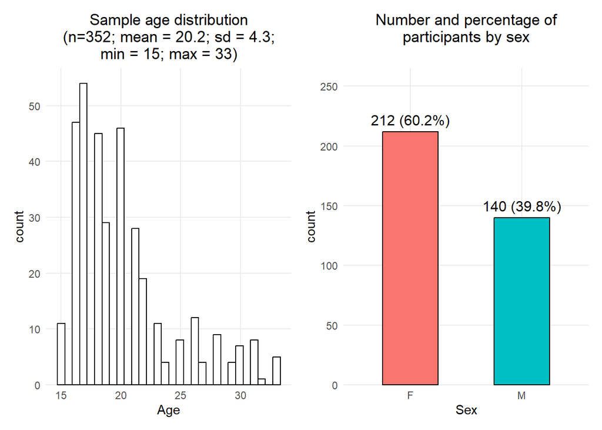

```
Here are values representing missing data for each variable in the final dataset
```

```
            ID     topography             FB            Sex            Age
             0              0              0              0              0
    theta_good absolute_power
             0              0
```

# Visualizing the Distribution of Absolute Power Within Topographies and in Relation to Age

The histograms of absolute power grouped for each topography are showing that the data is pretty skewed to the right. This is problematic because in order for us analyze our data we need to see a normal distribution to produce stable and reliable standard errors. Now this is not always the case, what really matters is the distribution of your errors, however this is a good shortcut to predict whether our errors will look normal or not.

In Whitford’s paper, they also report that their distribution of absolute power for their sample was skewed also to the right. Since their analysis involved using regression, they needed their outcome distribution (absolute power) to look normal, thus they square root their data.

Below we are doing something similar, we are plotting the distribution of absolute power in its original scale, after the values were transformed with the square root and a transformation of values using logarithm. We see below that our data looks best (normally distributed) when we use the log transformations.

Additionally we are also showing the scatterplot between that transformation of the outcome (absolute power) and age. These descriptives give us a hint on whether or not we see that with age absolute power decreases, which theoretically is something we would expect.

We can kinda see this with the slow wave, where with age the absolute power of the slow wave (0.5 - 7.5 Hz) decreases, however for alpha and beta we do not see this relationship.

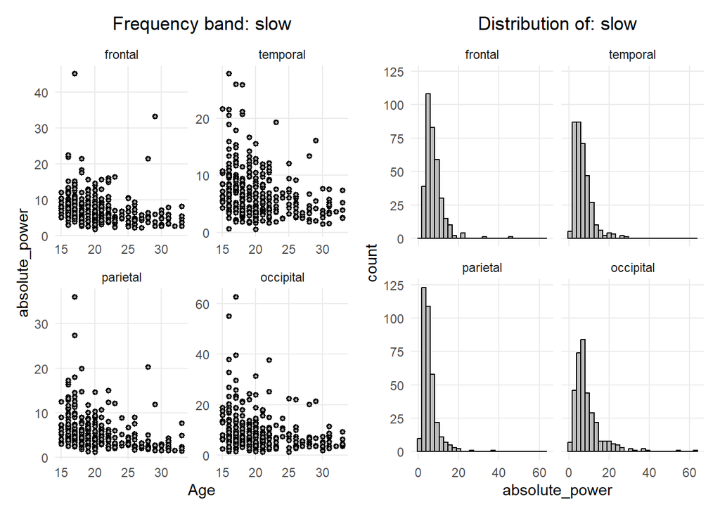

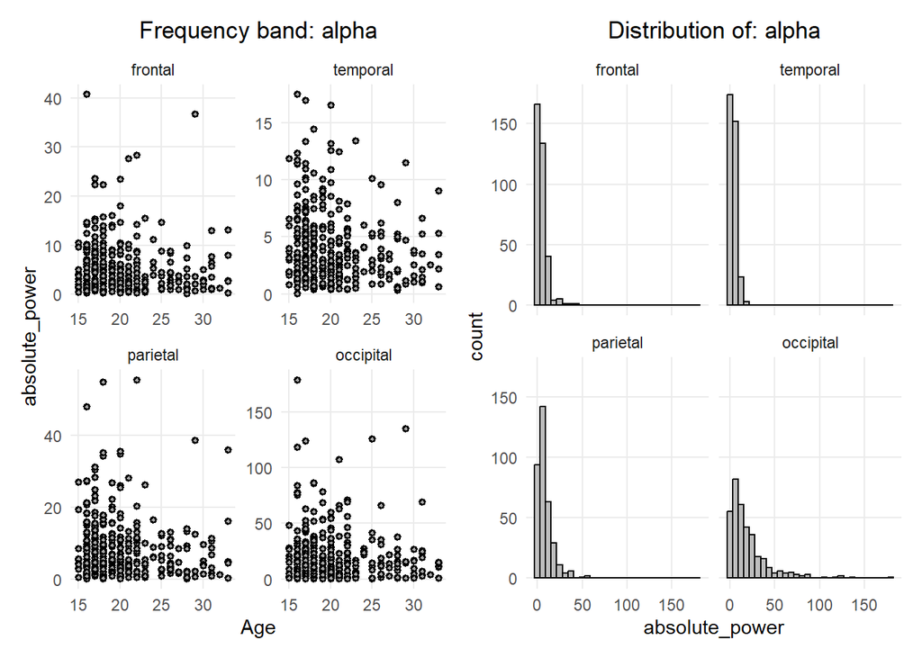

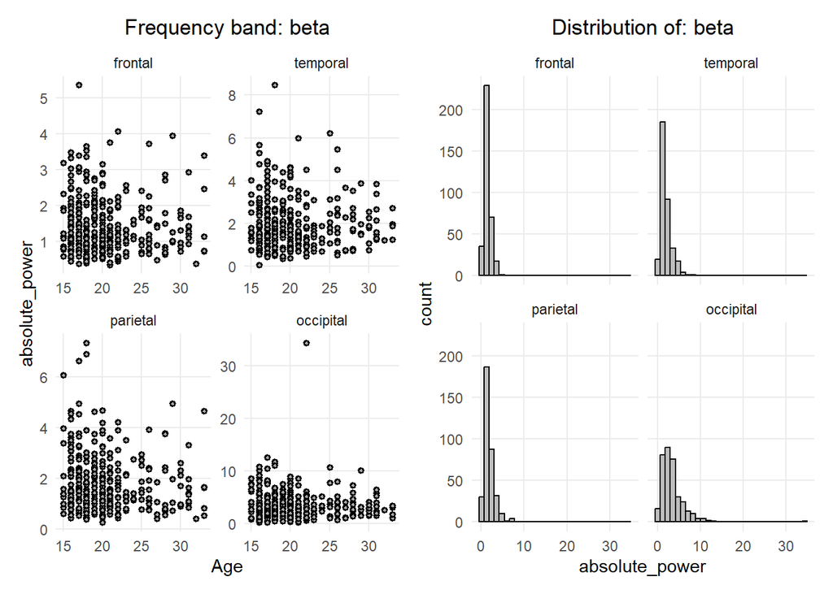

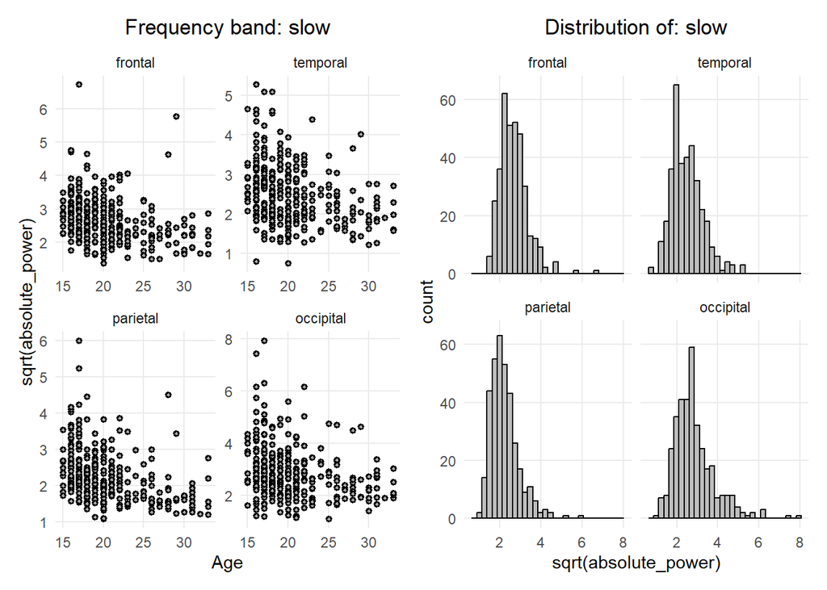

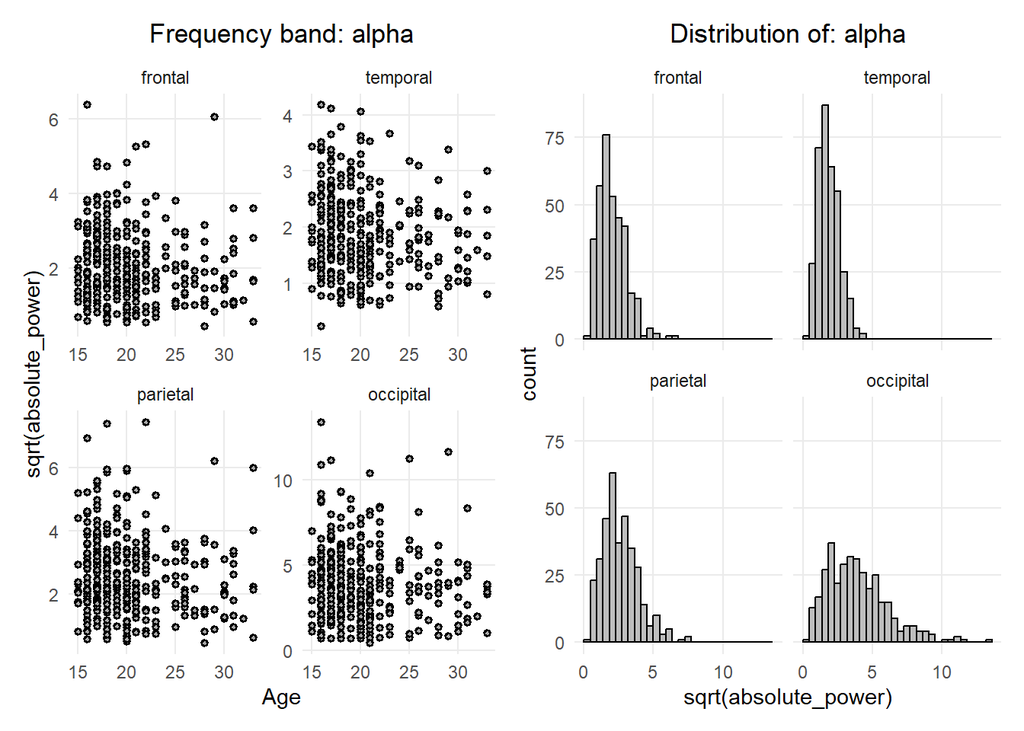

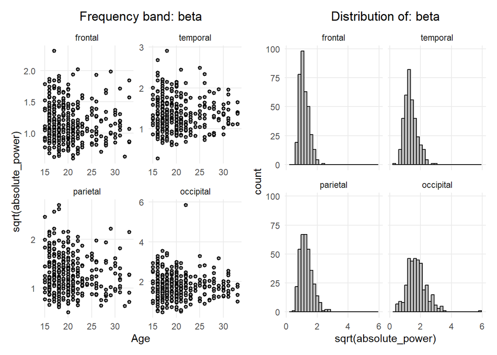

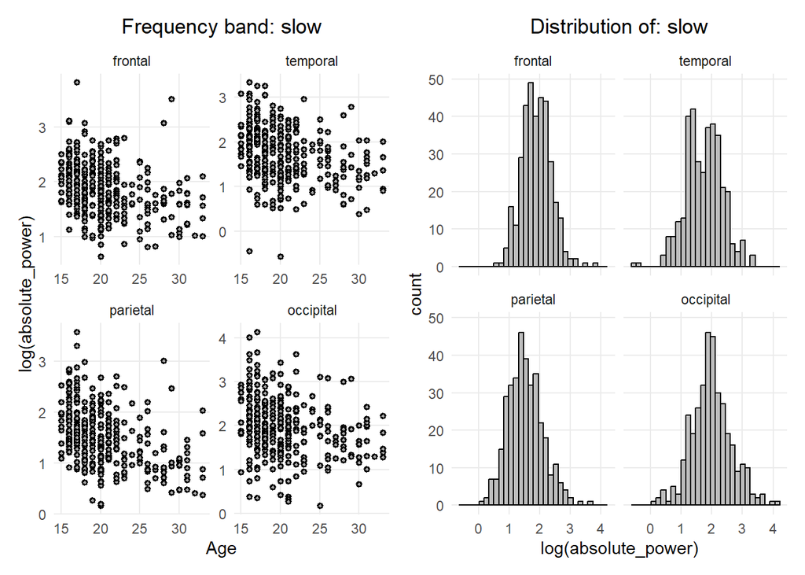

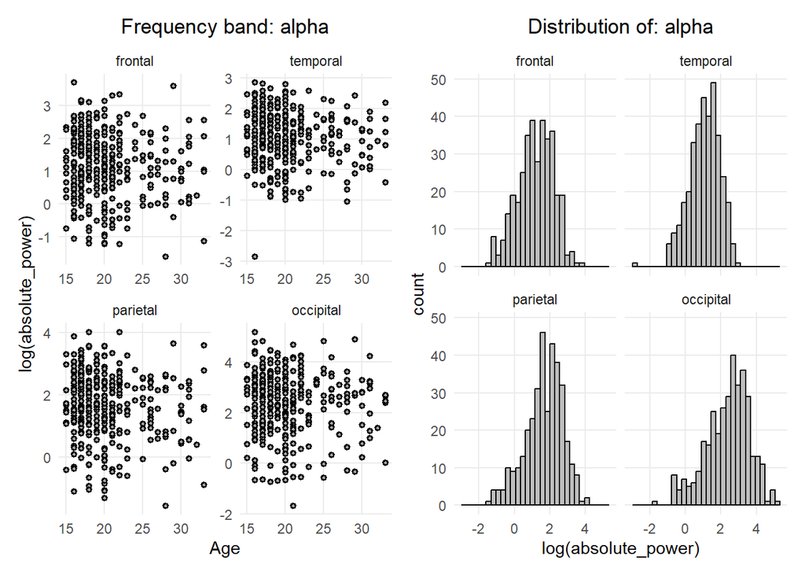

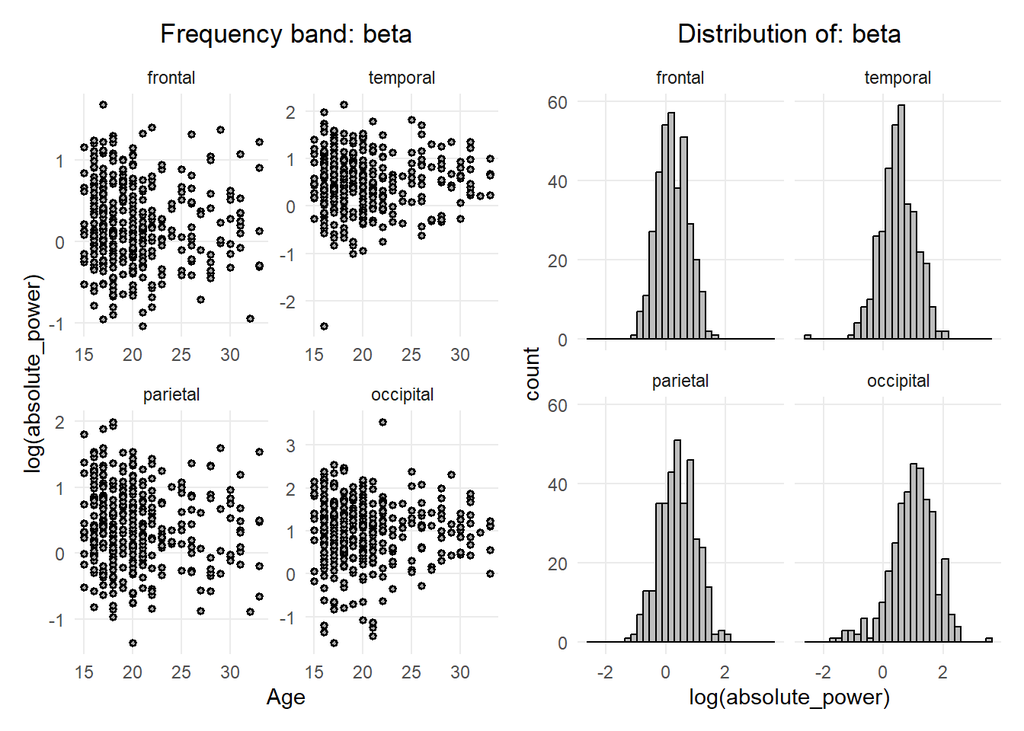

# Create Spelling Performance Group Using Fitted Values from Quadratic to Plateau Model

[We deleted the section before showing a scatterplot between Age and Spelling Ability because who cares, we show the same thing below but with more information]

To address the concerns above, we can fit a quadratic to plateau model to model Spelling Ability as a function of Age. This will produce fitted values (aka the expected spelling score for each level of Age) that we can use to our advantage. We can take the difference of the observed value from the fitted value and then quantify this difference into quantiles. Those in the bottom 20% percentile will become the poor performance spellers while the rest will be the good performance spellers.

The advantage of this approach is that it basically categorizes poor spellers as individuals who performed poorly in comparison to individuals of a similar age. Also, the spelling ability scores were derived from a much larger sample, actually from the sample of all IDs that had spelling data. This is good because that sample was 661 subjects. Now while I am no IRT expert, I think this large of a sample size plus the fact that there were poor performers in the spelling task based on raw scores, justifies that standardized values, which represent distance from the mean performers, is still capturing true poor spellers.

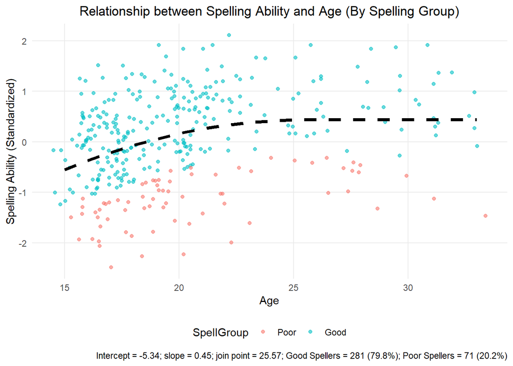

# Age and Spelling Group Tabulation Table (Contingency Table)

Now that we have created a spelling group factor, let’s see what the cell sample sizes are. We will bin people into age groups and then show within those bins, how many good and poor spellers there are.

Number of Good and Poor Spellers by Age Group

| Age_group | Poor | Good | Sum |
| --- | --- | --- | --- |
| 15-17 | 18 | 94 | 112 |
| 18-21 | 27 | 93 | 120 |
| 21-26 | 15 | 67 | 82 |
| 27-33 | 11 | 27 | 38 |
| Sum | 71 | 281 | 352 |

### Visualize the Relationship Between Spelling and EEG power

Visually it looks like spelling ability does not seem to be predictive at all of rsEEG absolute power. This is preparing us for the fact that we are very likely not going to see any differences between good and poor spellers- their EEG activity looks the same.

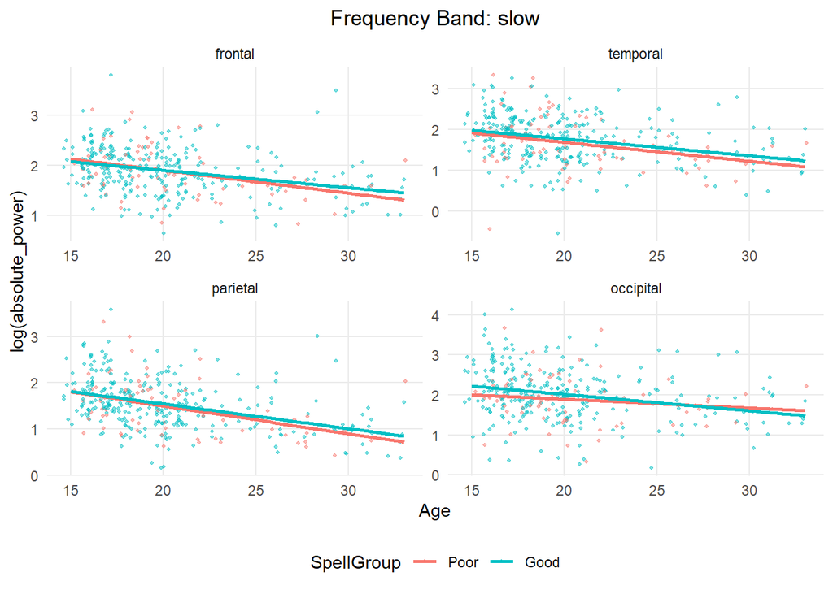

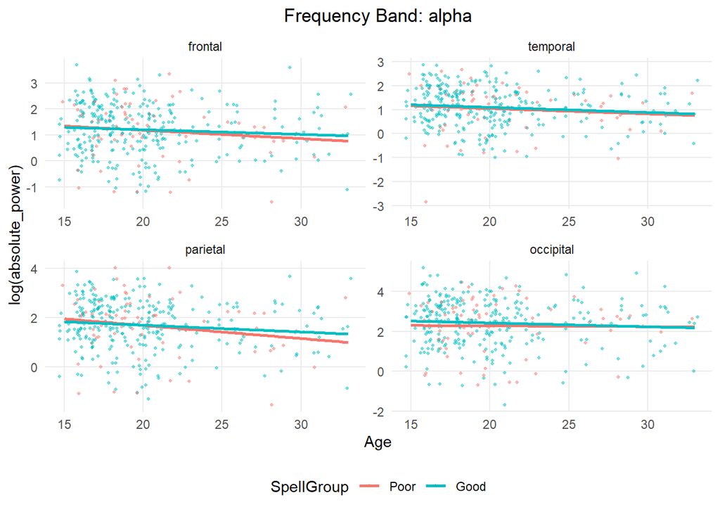

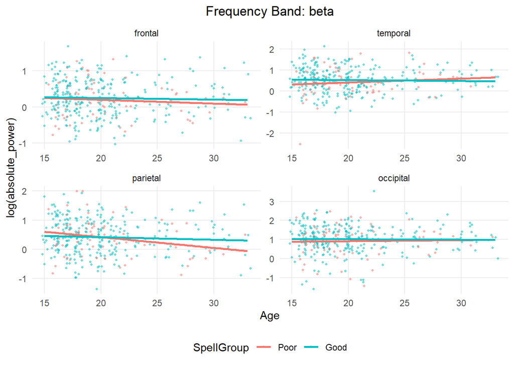

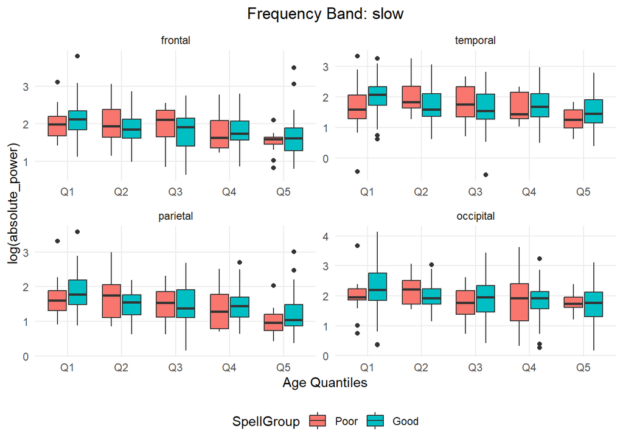

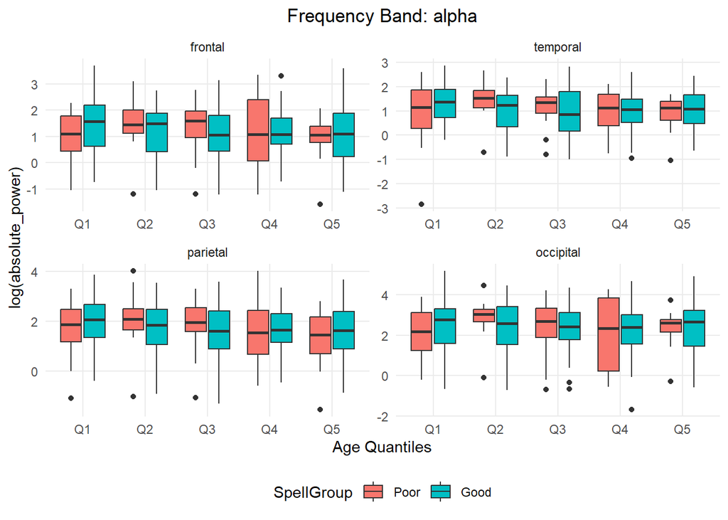

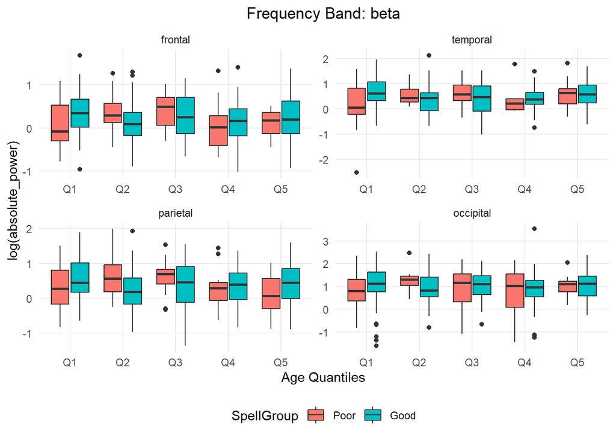